# Visualising spatial data in R

To remove the background from ggplots we can add the following to the `ggplot` command we have just run. As we have saved the previous plot as a ggplot object we can add further commands using + . Background elements are all editied from within the theme command (`theme()`):

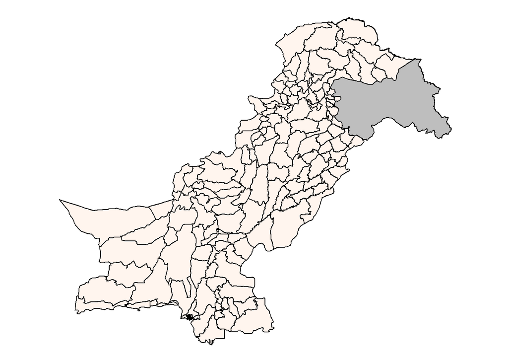

```r
 Pak_map + theme(axis.line=element_blank(),           # remove axis lines
                 axis.text.x=element_blank(),         # remove x axis numbers
                 axis.text.y=element_blank(),         # remove y axis numbers
                 axis.ticks=element_blank(),          # remove markers for the numbers
                 axis.title.x=element_blank(),        # remove x axis title
                 axis.title.y=element_blank(),        # remove y axis title
                 panel.background=element_blank(),    # remove the white background around the axes
                 panel.border=element_blank(),        # remove the border around the plot
                 panel.grid.major=element_blank(),    # remove grid lines
                 panel.grid.minor=element_blank(),    # remove grid lines
                 plot.background=element_blank(),     # remove the grey background
                 plot.margin=unit(c(0,0,0,0), "cm"))  # remove empty space around the plot
```

We can also add annotations to the ggplot object using `annotate` and the coordinates of the point we want to label, update Pak_map in your environment by overwriting it with this new map:

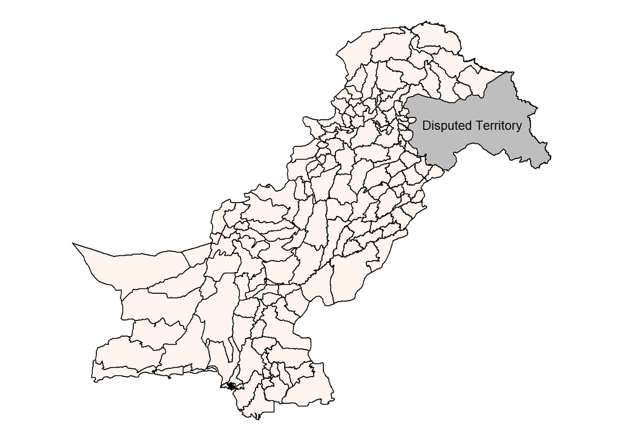

```r
 Pak_map <- Pak_map + theme(axis.line=element_blank(),
                 axis.text.x=element_blank(),
                 axis.text.y=element_blank(),
                 axis.ticks=element_blank(),
                 axis.title.x=element_blank(),
                 axis.title.y=element_blank(),
                 panel.background=element_blank(),
                 panel.border=element_blank(),
                 panel.grid.major=element_blank(),
                 panel.grid.minor=element_blank(),
                 plot.background=element_blank(),
                 plot.margin=unit(c(0,0,0,0), "cm"))+
  annotate("text", x = 76.5, y = 33.8, label = "Disputed Territory", size= 3.5)

# running the name of a ggplot object will plot the object for you
Pak_map
```

All of our plots so far have been blank with no associated data to plot. we will now import some of the polio data provided for the course and try plotting this with ggplot.

## Plotting some data

Adding data to the existing spatial polygons data frames allows us to plot different attributes on the maps. In these examples we will use three types of polio data you are likely to come accross regularly.

### LQAS

Read in the LQAS percentage pass file and save as `LQAS_PASS` in your environment. The columns we need to match this data to the maps are named differently so we need to rename these to match. Add your own code to rename “District” as “ADM2_NAME”

```r
LQAS_PASS <- read_excel("../LQAS %Pass _ District level_ Sep18-Mar19.xlsx")
```

```r
colnames(LQAS_PASS)[colnames(LQAS_PASS)=="Province"] <- "ADM1_NAME"
```

```r
colnames(LQAS_PASS)[colnames(LQAS_PASS)=="District"] <- "ADM2_NAME"
```

Some province and district names are also not matched to the map data we have been working with. To see which these are use the `%in%` command.

```r
ADM_2_PK$ADM1_NAME[!ADM_2_PK$ADM1_NAME %in% LQAS_PASS$ADM1_NAME]
ADM_2_PK$ADM2_NAME[!ADM_2_PK$ADM2_NAME %in% LQAS_PASS$ADM2_NAME]
```

Using `View` to look at the LQAS_PASS data we can see that a number of the province names are shortened in the data frame. Use the following code to replace the district and province names with the ones used in the map data using dplyr:

```r
# Province names shortened in LQAS data frame - change to long form (match map)
require(dplyr)

LQAS_PASS$ADM1_NAME <- recode(LQAS_PASS$ADM1_NAME,
                            "KP"="KHYBER PAKHTOON",
                              "BALOCH"="BALOCHISTAN",
                              "GB"="GILGIT BALTISTAN",
                              "KPTD"="FATA",
                              "ISB"="ISLAMABAD"
                            )
# Different district spellings
LQAS_PASS$ADM2_NAME <- recode(LQAS_PASS$ADM2_NAME,
                               "UMERKOT"="UMARKOT",
                                 "DIAMER"="DIAMIR",
                                 "SHEIKHUPURA"="SHEIKUPURA",
                                 "BUNER"="BUNIR"
                            )
```

If we make a copy of the `@data` slot from `ADM_2_PK` we can match the data we wish to add to the rows already present in the table. Adding an id column allows us to match these rows to the fortified data:

```r
ADM_2_PK@data$id <- rownames(ADM_2_PK@data)
# merge the data matching by administrative level names
temp_mapdata <- merge(ADM_2_PK@data, LQAS_PASS, by=c("ADM1_NAME","ADM2_NAME"), all=T)
FORTIFY_LQAS<- merge(ADM_2_PK_FORTIFY, temp_mapdata[,c("id", "%Pass")], by="id")
```

Now we can plot this data using ggplot. For this example we will add it to the existing `Pak_map` we created earlier as a new polygon layer. we will add a parameter to the aesthetics specifying that we wish to fill by `%pass`. as this column starts with a special character we need to put it in back quotes otherwise we will get an error in R. You could also rename the column to fix this issue.

```r
Pak_map + geom_polygon(data=FORTIFY_LQAS, aes(y=lat, x=long, group=group, fill=`%Pass`))
```

This will give a heat map of percentage pass per district but when looking at LQAS we are interested in the cutoff points for high pass, pass, fail etc. To specify these cut points in the aesthetics of the plot we can use `cut()`. This function also lets us specify labels for each of the sections we cut the data in to:

```r
Pak_map + geom_polygon(data=FORTIFY_LQAS,
                  aes(y=lat, x=long, group=group,
                        fill=cut(`%Pass`, c(-Inf,79.5,84.5,89.5,94.5,Inf),
                              labels=c("<80%","80-84%","85-89%","90-94%","95%+"))),
                  color="grey")
```

This map will be ugly but will incorporate the cut points we have specified and their labels. We now need to edit the legend for this fill to fix the title and choose colours for each of the cut points we have chosen. For the colours I have used HEX colours, google HEX colour picker to see how these work. These can be directly entered in to R in place of the pre-programmed colours we used earlier.

```r
Pak_map + geom_polygon(data=FORTIFY_LQAS,
                       aes(y=lat, x=long, group=group,
                           fill=cut(`%Pass`, c(-Inf,79.5,84.5,89.5,94.5,Inf),
                                    labels=c("<80%","80-84%","85-89%","90-94%","95%+"))),
                       color="grey")+
    scale_fill_manual(
      name="% Lot Pass", # Name for the legend
      values = c("#e30000", "#e8ab02", "#c9f2b6", "#46a649", "#29782b", "white"),
      na.value="white") # specify some colours
```

We can plot the Provinces over this map using `geom_path`. This will plot only the outlines of the polygons so that we can see the data plotted below:

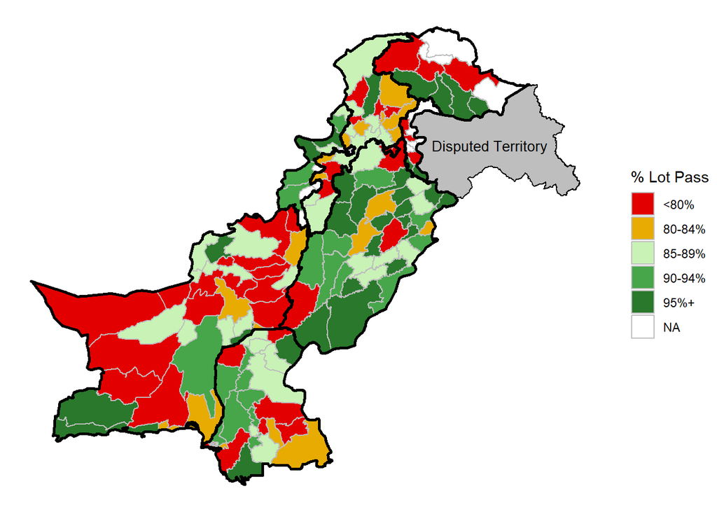

```r
Pak_map + geom_polygon(data=FORTIFY_LQAS,
                aes(y=lat, x=long, group=group,
                    fill=cut(`%Pass`, c(-Inf,79.5,84.5,89.5,94.5,Inf),
                            labels=c("<80%","80-84%","85-89%","90-94%","95%+"))),
                color="grey")+
    scale_fill_manual(name="% Lot Pass", # Name for the legend
                values = c("#e30000", "#e8ab02", "#c9f2b6", "#46a649", "#29782b", "white"),
                na.value="white")+
    geom_path(data=ADM_1_PK, aes(y=lat, x=long, group=group), colour="black", size=1)
```

## Non-polio AFP rate

To plot the NPAFP rate we first have to calculate it from the population and the number of reported cases on NPAFP. Datasets for both of these have been provided. Read in the population data from the excel file and name it `POP`.

```r
POP <- read_excel("../Population under 15-estimates 2018-19 as 190510.xlsx")
```

There is a total at the bottom of the population column which we will need to remove, this can be done with the following code or removed in excel before importing the data.

```r
POP <- POP[-c(171),]
```

Also import the non-polio AFP rate data and name this `NPAFP`.

```r
NPAFP <- read_excel("../List of NON POLIO AFP Cases 2015-2019.xlsx", range = cell_cols("A:N"))
```

We will extract 2018 and 2019 from the NPAFP dataset as these are the years we want to plot.

```r
NPAFP18_19 <- NPAFP[NPAFP$YRONSET %in% c("2018","2019"),]
```

Both of these files have column names “PROVINCE” and “DISTRICT”, rename these in the same way we did for the LQAS data.

```r
colnames(NPAFP18_19)[colnames(NPAFP18_19)=="PROVINCE"] <- "ADM1_NAME"
colnames(NPAFP18_19)[colnames(NPAFP18_19)=="DISTRICT"] <- "ADM2_NAME"
colnames(POP)[colnames(POP)=="PROVINCE"] <- "ADM1_NAME"
colnames(POP)[colnames(POP)=="DISTRICT"] <- "ADM2_NAME"
```

We want to sum the non-polio AFP cases by district and year of onset, we can do that with the following code by adding a column of 1s that we can sum to give a count. We then use reshape2 to cast the table in to a more traditional data frame with columns for each year and rows for each district.

```r
NPAFP18_19$CASE <- 1 # add a column to sum
NPAFP18_19_ag <- aggregate(CASE ~ YRONSET + ADM2_NAME, NPAFP18_19, sum) #sum
require(reshape2)
NPAFP18_19_ag <- dcast(NPAFP18_19_ag, ADM2_NAME~YRONSET) # transform into wide format
```

```r
NPAFP18_19_ag$ADM2_NAME <- recode(NPAFP18_19_ag$ADM2_NAME, "JEHLUM_VALLEY"="HATTIAN")

NPAFP_R8 <- merge(NPAFP18_19_ag, POP, by="ADM2_NAME", all=T)
NPAFP_R8$RATE_18 <- (NPAFP_R8$`2018`/NPAFP_R8$`POPL15 (2018)`)*100000
NPAFP_R8$RATE_19 <- (NPAFP_R8$`2019`/NPAFP_R8$`POPL15 (2019)`)*100000
```

We then need to rename the districts and provinces to match the map data and plot as we did for the previous example.

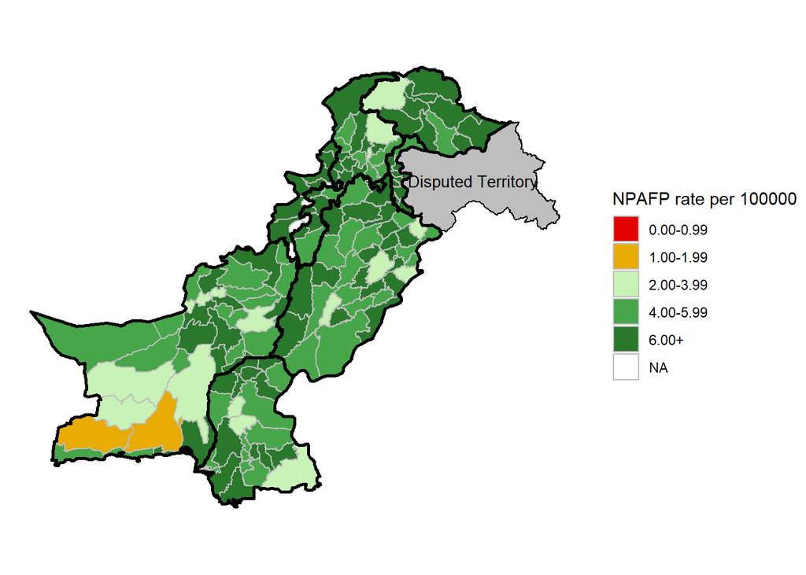

```r
NPAFP_R8$ADM1_NAME <- recode(NPAFP_R8$ADM1_NAME,
                                "KP"="KHYBER PAKHTOON",
                                "GBALTISTAN"="GILGIT BALTISTAN",
                                "KPTD"="FATA"
                               )
NPAFP_R8$ADM2_NAME <- recode(NPAFP_R8$ADM2_NAME,
                              "UMERKOT"="UMARKOT",
                              "DIAMER"="DIAMIR",
                              "SHEIKHUPURA"="SHEIKUPURA",
                              "BUNER"="BUNIR"
                              )


temp_mapdata <- merge(ADM_2_PK@data, NPAFP_R8, by=c("ADM2_NAME"), all=T)

NPAFP_FORTIFY <- merge(ADM_2_PK_FORTIFY, temp_mapdata[,c("id", "RATE_18", "RATE_19")], by="id")

Pak_map + geom_polygon(data=NPAFP_FORTIFY,
                aes(y=lat, x=long, group=group,
                    fill=cut(RATE_19, c(-Inf,0.99,1.99,3.99,5.99,Inf),
                            labels=c("0.00-0.99","1.00-1.99","2.00-3.99","4.00-5.99","6.00+"))),
                color="grey")+
          geom_path(data=ADM_1_PK, aes(y=lat, x=long, group=group),
                    colour="black", size=1)+
          scale_fill_manual(name="NPAFP rate per 100000",
                      values = c("#e30000", "#e8ab02", "#c9f2b6", "#46a649", "#29782b", "white"),
                      na.value="white", drop=F)
```

This plots a map for 2019 to date, look at the code and see if you can plot the same map for 2018.

```r
Pak_map + geom_polygon(data=NPAFP_FORTIFY,
                aes(y=lat, x=long, group=group,
                    fill=cut(RATE_18, c(-Inf,0.99,1.99,3.99,5.99,Inf),
                             labels=c("0.00-0.99","1.00-1.99","2.00-3.99","4.00-5.99","6.00+"))),
                color="grey")+
          geom_path(data=ADM_1_PK, aes(y=lat, x=long, group=group),
                    colour="black", size=1)+
          scale_fill_manual(name="NPAFP rate per 100000",
                      values = c("#e30000", "#e8ab02", "#c9f2b6", "#46a649", "#29782b", "white"),
                      na.value="white", drop=F)
```

## Case data

To plot case data we need to use points rather than filling the polygons. A dataset of all AFP cases is provided, import this in to R and extract only WPV1 cases from the VIRUS column in to a data frame called `PV_cases`. The “PROVINCE” and “DISTRICT” columns will also need to be renamed as before. NOTE: we want sheet 3 from this excel spreadsheet, this can be specified with sheet=3

```r
ALL_AFP <- read_excel("../List of AFP Cases 2015-2019.xlsx", sheet=3)
PV_Cases <- ALL_AFP[ALL_AFP$VIRUS=="WPV1",]
colnames(PV_Cases)[colnames(PV_Cases)=="PROVINCE"] <- "ADM1_NAME"
colnames(PV_Cases)[colnames(PV_Cases)=="DISTRICT"] <- "ADM2_NAME"
```

Some names don’t match the map data:

```r
PV_Cases$ADM1_NAME <- recode(PV_Cases$ADM1_NAME,
                               "KP"="KHYBER PAKHTOON",
                                 "GBALTISTAN"="GILGIT BALTISTAN",
                                 "KPTD"="FATA"
                               )
# Different district spellings
PV_Cases$ADM2_NAME <- recode(PV_Cases$ADM2_NAME,
                               "UMERKOT"="UMARKOT",
                                 "DIAMER"="DIAMIR",
                                 "SHEIKHUPURA"="SHEIKUPURA",
                                 "BUNER"="BUNIR"
                               )
```

We will sum polio cases in the same way as the non-polio AFP cases. Adapt the code given above for NPAFP and apply to PV_Cases. Name the output file PV_Cases_sum.

```r
PV_Cases$CASE <- 1 # add a column to sum
PV_Cases_sum <- aggregate(CASE ~ YRONSET + ADM2_NAME, PV_Cases, sum) #sum
PV_Cases_sum <- dcast(PV_Cases_sum, ADM2_NAME~YRONSET) # transform into wide format
```

This time we will create a copy of the spatial polygons data frame and attach our new data to this. We do not need to fortify to plot point data on a map:

```r
ADM_2_PK_Cases <- ADM_2_PK
ADM_2_PK_Cases <- raster::aggregate(ADM_2_PK_Cases, by=c("ADM1_NAME", "ADM2_NAME"), all=T)
ADM_2_PK_Cases@data$id <- rownames(ADM_2_PK_Cases@data)

temp_mapdata <- merge(ADM_2_PK_Cases@data, PV_Cases_sum, by=c("ADM2_NAME"), all=T)

# set all the NA values to 0
temp_mapdata[is.na(temp_mapdata$`2019`),]$`2019` <- 0
temp_mapdata[is.na(temp_mapdata$`2018`),]$`2018` <- 0
temp_mapdata[is.na(temp_mapdata$`2017`),]$`2017` <- 0
temp_mapdata[is.na(temp_mapdata$`2016`),]$`2016` <- 0
temp_mapdata[is.na(temp_mapdata$`2015`),]$`2015` <- 0

ADM_2_PK_Cases@data <- merge(ADM_2_PK_Cases@data,temp_mapdata, by=c("id"), all=T)
```

We need to set all of the NA values in the table to 0 in order to work with the function we use to plot the data. As we do not have exact locations for the cases we can approximate their locations using the `dotsInPolys` function. This will plot the correct number of cases randomly within the district where they were reported, which is not accurate but can be used as a visual aid in a presentation or document. Not providing exact locations helps to annonymise the identity of polio patients.

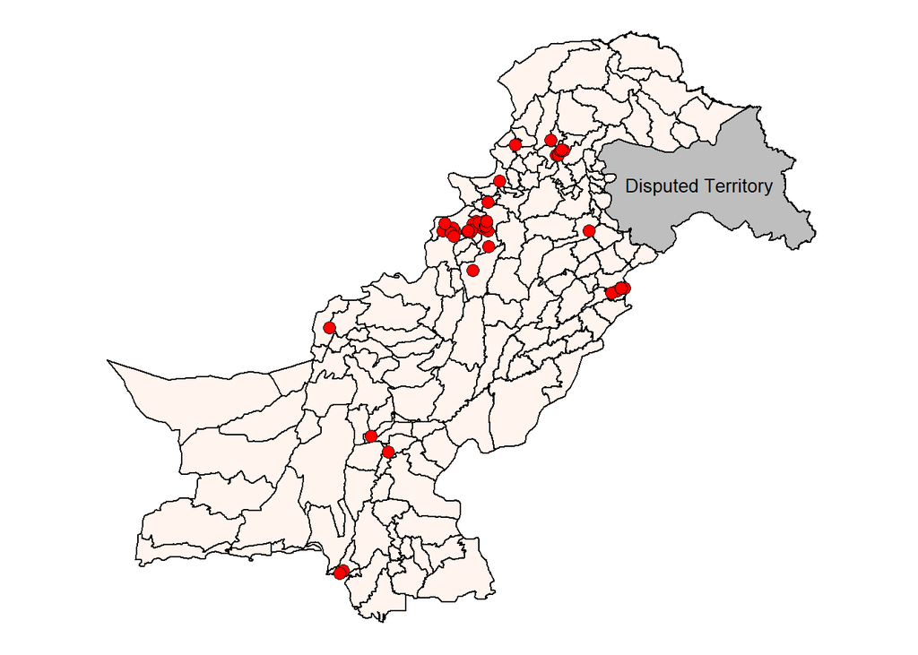

```r
try2019 <- data.frame(dotsInPolys(ADM_2_PK_Cases, as.integer(ADM_2_PK_Cases$`2019`)))

Pak_map + geom_point(data=try2019, aes(y=y, x=x),shape=21, size=3, fill="red")
```

Try adapting the code to plot cases for different years.